# econ2200Ch11 slides

## ECON2200H

### Introduction to Statistics for Economics and Management

### 2020 Winter Term

### Week 10: Comparing two population variances

#### 16 March 2020

### Reading: Chapter 11 of textbook Section 1.

## Outline

- Compare equality of two population variances

## 1. Chi-square distribution and $F$ distribution

- This section is optional.
- If $Z$ has the standard normal distribution, then $Z^2$ has the **chi-square distribution with 1 degree of freedom**.
- If $Z_1, Z_2, \cdots, Z_n$ are independent random variables, each of them has the standard normal distribution. Let $V = Z_1^2+Z_2^2+\cdots+Z_n^2$, then $V$ has the **chi-square distribution with n degrees of freedom**.
- If $U$ and $V$ are independent random variables, $U$ has the chi-square distribution with $m$ degrees of freedom, and $V$ has the chi-square distribution with $n$ degrees of freedom. Then $$W = \frac{U/m}{V/n}$$ has a **$F$ distribution with $m$ and $n$ degrees of freedom**.
- Probability density functions of Chi-square and F random variables

[figure not shown]

#### Some facts regarding distributions

- Two independent random variables $Z$ and $V$. If $Z$ has the standard normal distribution, and $V$ has the chi-square distribution with $n$ degrees of freedom, then $\frac{Z}{\sqrt{V/n}}$ has the $t$ distribution with $n$ degrees of freedom.
- If random variable $W$ has the $F$ distribution with $m$ and $n$ degrees of freedom, then its reciprocal $\frac{1}{W}$ has the $F$ distribution with $n$ and $m$ degrees of freedom.
- If $T$ has the $t$ distribution with $n$ degrees of freedom, then $T^2$ has the $F$ distribution with $1$ and $n$ degrees of freedom.

## 2. Comparing two population variances

- Two random samples.
- One random sample $(X_1,X_2,\cdots,X_m)$ of size $m$ is drawn from a normal distribution with mean $\mu_X$ and variance $(\sigma_X)^2$.
- The other random sample $(Y_1,Y_2,\cdots,Y_n)$ of size $n$ is drawn from a normal distribution with mean $\mu_Y$ and variance $(\sigma_Y)^2$.
- Recall, $\overline{X}$ is the sample mean, $(s_X)^2$ is the sample variance, and \begin{equation}(s_X)^2 = \frac{1}{m-1} \sum_{i=1}^m (X_i-\overline{X})^2.\end{equation}
- Also recall, the variance of $\overline{X}$ is $(s_{\overline{X}})^2 = \frac{(s_X)^2}{m}$.
- **Claim**: $W = \frac{s_X^2}{s_Y^2}$ has the $F$ distribution with $m-1$ and $n-1$ degrees of freedom.
- (Optional) Sketch of why. Define \begin{equation}(S_X)^2 =\sum_{i=1}^m (X_i-\overline{X})^2,\end{equation} then $s_X^2 = \frac{1}{m-1} S_X^2$.
- $(X_i-\overline{X})$ has the standard normal distribution for all $i$.
- Then, $S_X^2$ has the chi-square distribution with $m-1$ degrees of freedom.
- Similarly, $S_Y^2$ has the chi-square distribution with $n-1$ degrees of freedom.
- By definition, $W = \frac{s_X^2}{s_Y^2} = \frac{S_X^2/(m-1)}{S_Y^2/(n-1)}$ has the $F$ distribution with $m-1$ and $n-1$ degrees of freedom.
- Comparing two population variances $\sigma_X^2$ and $\sigma_Y^2$.
- Hypothesis can be one-sided,$$H_0: \sigma_X^2 \le \sigma_Y^2 \\ H_1: \sigma_X^2 > \sigma_Y^2.$$
- The test statistic $W = \frac{s_X^2}{s_Y^2}$ has the $F$ distribution with $m-1$ and $n-1$ degrees of freedom.
- Reject the null $H_0$ if the value of test statistic $W$ is greater than the critical value, where the critical value is chosen under a desired level of significance.
- Hypothesis can also be two-sided,$$H_0: \sigma_X^2 = \sigma_Y^2 \\ H_1: \sigma_X^2 \ne \sigma_Y^2.$$
- If test is two-sided, reject the null $H_0$ if the value of test statistic $W$ is not between two critical values.
- Example: Testing equality of two population variances. Time of packing cartons with jars by old and new machines.

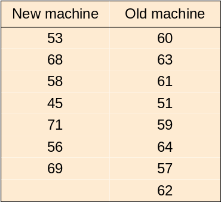

- Want to test whether the variation of packing time differs between old and new machines.
- Sample size $m=7, n = 8$. $\overline{X} = 60.00, \overline{Y}=59.625$.
- Further, $s_{X}^2 = 93.333$ and $s_Y^2=17.125$.
- Hypotheses $$H_0: \sigma_X^2 \le \sigma_Y^2 \\ H_1: \sigma_X^2 > \sigma_Y^2.$$
- Choose a significance level, say set it to 0.05.
- The test statistic $W = \frac{s_X^2}{s_Y^2}$ has the $F$ distribution with $m-1$ and $n-1$ degrees of freedom.
- Decision rule: reject the null $H_0$ if the value of $W$ exceeds the critical value 3.87, critical value is obtained from the $F$ distribution table with $\alpha=0.05$ and 6 and 7 degrees of freedom.
- Note the test is one-sided.
- The test statistic is $W = \frac{93.333}{17.125} = 5.45$.
- Decision: reject the null $H_0$ at 0.05 significance level since 5.45 >3.87.
- We use the ratio of variances to test the equality of population variance, because that ratio follows a known distribution, the $F$ distribution.
- We reject the null if the value of $W$ is greater than a critical value $c$.
- The critical value $c$ depends on the degrees of freedom and the significance level.